# Getting Started

*gganimate* is an extension of the *grammar of graphics*, as implemented by the [*ggplot2*](https://ggplot2.tidyverse.org) package, that adds support for declaring animations using an API familiar to users of *ggplot2*.

> The following introduction assumes familiarity with *ggplot2* to the extend that constructing static plots and reading standard *ggplot2* code feels natural. If you are new to both *ggplot2* and *gganimate* you’ll benefit from exploring the trove of *ggplot2* documentation, tutorials, and courses available online first (see the [*ggplot2* webpage](https://ggplot2.tidyverse.org/#learning-ggplot2) for some pointers).

## Your First Animation

We’ll jump right into our first animation. Don’t worry too much about understanding the code, as we’ll dissect it later.

```r
library(gganimate)
```

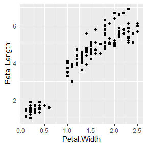

```r
# We'll start with a static plot
p <- ggplot(iris, aes(x = Petal.Width, y = Petal.Length)) +
  geom_point()
plot(p)
```

You go from a static plot made with *ggplot2* to an animated one, simply by adding on functions from *gganimate*.

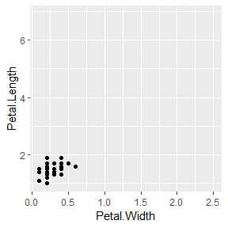

```r
anim <- p +
  transition_states(Species,
                    transition_length = 2,
                    state_length = 1)
anim
```

> ❗ `transition_states()` splits up plot data by a discrete variable and animates between the different states. As can be seen, very few additions to the plot results in a quite complex animation. So what did we do to get this animation? We added a type of *transition*. Transitions are functions that interpret the plot data in order to somehow distribute it over a number of frames. `transition_states()` specifically splits the data into subsets based on a variable in the data (here `Species`), and calculates intermediary data states that ensures a smooth transition between the states (something referred to as *tweening*). *gganimate* provides a range of different transitions, but for the rest of the examples we’ll be sticking to `transition_states()` and see how we can modify the output.

## Easing

When `transition_states()` calculates intermediary data for the tweening, it needs to decide how the change from one value to another should progress. This is a concept called *easing*. The default easing is *linear*, but others can be used, potentially only targeting specific aesthetics. Setting easing is done with the `ease_aes()` function. The first argument sets the default easing and subsequent named arguments sets it for specific aesthetics.

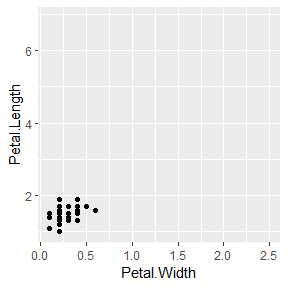

```r
anim +
ease_aes('cubic-in-out') # Slow start and end for a smoother look
```

> ❗ `ease_aes()` defines the velocity with which aesthetics change during an animation.

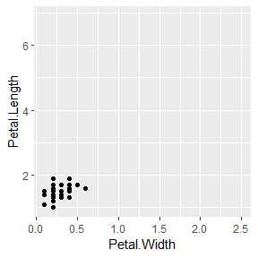

```r
anim +
ease_aes(y = 'bounce-out') # Sets special ease for y aesthetic
```

## Labeling

It can be quite hard to understand an animation without any indication as to what each time point relates to. *gganimate* solves this by providing a set of variables for each frame, which can be inserted into plot labels using [*glue*](https://glue.tidyverse.org) syntax.

```r
anim +
ggtitle('Now showing {closest_state}',
subtitle = 'Frame {frame} of {nframes}')
```

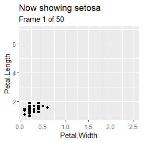

> ❗ Use *glue* syntax to insert frame variables in plot labels and titles. Different transitions provide different frame variables. `closest_state` only makes sense for `transition_states()` and is thus only available when that transition is used.

## Object Permanence

In the animation above, it appears as if data in a single measurement changes gradually as the flower being measured on somehow morphs between three different iris species. This is probably not how Fisher conducted the experiment and got those numbers. In general, when you make an animation, *graphic elements should only transition between instances of the same underlying phenomenon*. This sounds complicated but it is more or less the same principle that governs makes sense to draw a line between two observations. You wouldn’t connect observations from different iris species, but repeated observations on the same plant would be fine to connect. Same thing with animations.

Just to make this very clear (it is an important concept). The line plot equivalent of our animation above is:

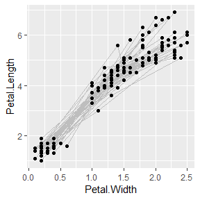

Ugh…

So, how do we fix this and tell *gganimate* to not morph observations from different species into each others? The key is the *group aesthetic*. You may be familiar with this aesthetic from plotting lines and polygons, but in *gganimate* it takes a more central place. Data that have the same group aesthetic are interpreted as being linked across states. The semantics of the group aesthetic in *ggplot2* is such that if it is undefined it will get calculated based on the interaction of all discrete aesthetics (sans `label`). If none exists, such as in our iris animation, all data will get the same group, and will thus be matched by *gganimate*. So, there are two ways to fix our plot:

1. Add some aesthetics that distinguish the different species

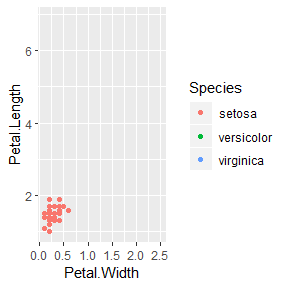

```r
ggplot(iris, aes(x = Petal.Width, y = Petal.Length)) +
  geom_point(aes(colour = Species)) +
  transition_states(Species,
                    transition_length = 2,
                    state_length = 1)
```

2. Set the group directly

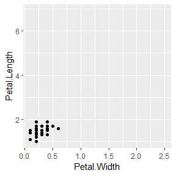

```r
ggplot(iris, aes(x = Petal.Width, y = Petal.Length)) +
  geom_point(aes(group = seq_along(Species))) +
  transition_states(Species,
                    transition_length = 2,
                    state_length = 1)
```

> ❗ The group aesthetic defines how the data in a layer is matched across the animation. In general *2)* is preferred as it makes the intend explicit. It also makes it possible to match data with different discrete aesthetics such as keeping our (now obviously faulty) transition while having different colour for the different species)

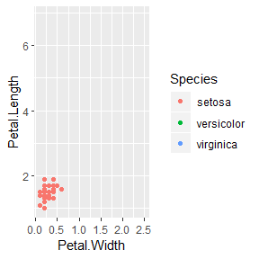

```r
ggplot(iris, aes(x = Petal.Width, y = Petal.Length)) +
  geom_point(aes(colour = Species, group = 1L)) +
  transition_states(Species,
                    transition_length = 2,
                    state_length = 1)
```

## Enter and Exit

While we may have made our animation more correct by separating the data from the different species, we have also made it quite a bit more boring. Now it simply appears as three static plots shown one at a time, which is hardly an attention grabber. If only there were a way to animate the appearance and disappearance of data…

Enter the `enter` and `exit` functions. These functions are responsible for modifying the state of appearing (entering) and disappearing (exiting) data, so that the animation can tween from and to the new state. Let’s spice up our animation a bit:

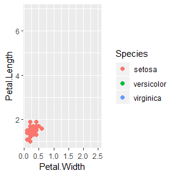

```r
anim <- ggplot(iris, aes(x = Petal.Width, y = Petal.Length)) +
geom_point(aes(colour = Species), size = 2) +
transition_states(Species,
transition_length = 2,
state_length = 1)
anim +
enter_fade() +
exit_shrink()
```

> ❗ `enter` and `exit` functions are used to modify the aesthetics of appearing and disappearing data so that their entrance or exit may be animated.

*gganimate* comes with a range of different functions, and using the `enter_manual()` and `exit_manual()` functions you can create your own. Enter and exit functions are composable though, so you can often come pretty far by combining preexisting ones

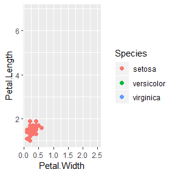

```r
anim +
enter_fade() + enter_drift(x_mod = -1) +
exit_shrink() + exit_drift(x_mod = 5)
```

## Rendering

In the examples above the animations has simply appeared when we printed the animation object, just like we would expect from *ggplot2*. As a lot of things are happening automatically, and you might want to take control, this section will give a brief overview of the rendering.

There are other arguments as well (e.g. `...` will be passed on to the device so you can set width, height, dpi, etc), but these are the most important. If you don’t like the defaults you can either call `animate()` directly with values of your choosing, or modify the defaults by setting new with `options(gganimate.<argument> = <value>)`.

A topic that requires some additional words are the renderers. The default will use gifski to combine the frames into a gif. gifs are great because they are virtually supported everywhere, and gifski is both a very fast, and very high quality converter. Still, you may have reasons to want a different output. *gganimate* is quite agnostic to how you want to combine the frames and, while it comes with a set of predefined renderers, any function that takes a vector of paths to image files along with a frame-rate, will do. The return value of your renderer is what is ultimately returned by the `animate()` function.

Below are a couple of examples of different `animate()` calls:

```r
# Video output
animate(
anim + enter_fade() + exit_fly(y_loc = 1),
renderer = av_renderer()
)
```

[video not shown]

```r
# Different size and resolution
animate(
anim + ease_aes(x = 'bounce-out') + enter_fly(x_loc = -1) + exit_fade(),
width = 400, height = 600, res = 35
)
```

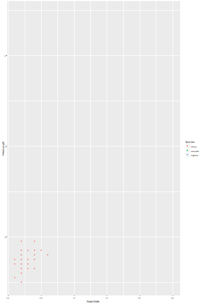

If you need to save the animation for later use you can use the `anim_save()` function. It works much like `ggsave()` from *ggplot2* and automatically grabs the last rendered animation if you do not specify one directly.

## Want more?

This guide is far from exhaustive, but have hopefully given you a broad understanding of how *gganimate* works. There are still more to explore as we have only scratched the surface of transitions, let alone mentioned views and shadows. But for now this is left to you. There is a fantastic joy in discovery and with the things you have now learned you are ready to go digging on your own.